# Titanic Class-Survival Gap Analysis: Decomposing Access & Constraints vs. Priority Rules

### 7.2 Final Visualization: Decomposition Summary

We visualize the decomposition of the class effect to illustrate the relative magnitudes of mechanisms:

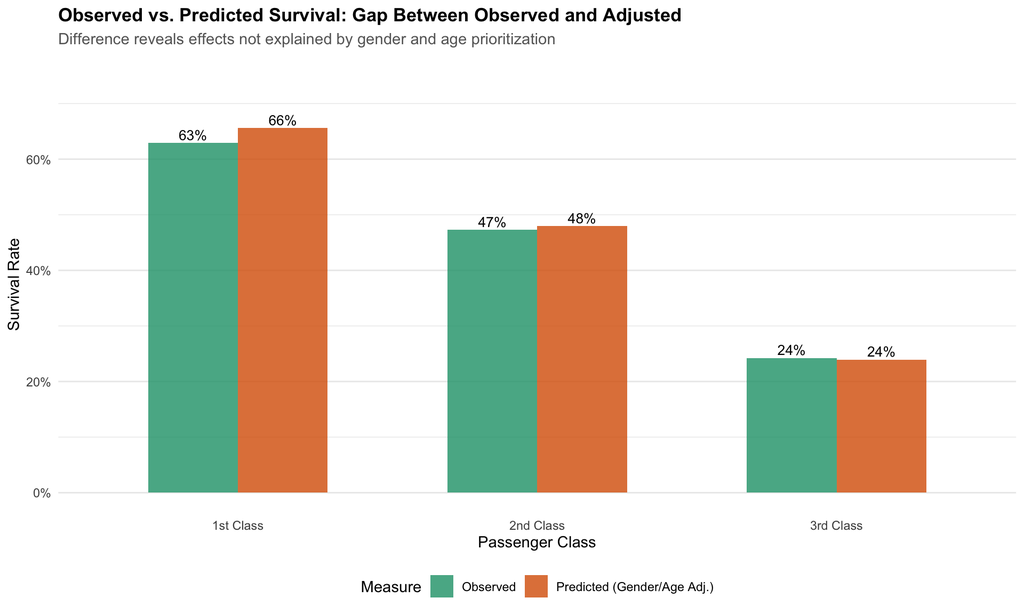

```r
# Create decomposition visualization
decomp_data <- data.frame(
  Class = c("1st Class", "2nd Class", "3rd Class"),
  Observed = c(
    filter(survival_by_class, pclass == 1)$survival_rate,
    filter(survival_by_class, pclass == 2)$survival_rate,
    filter(survival_by_class, pclass == 3)$survival_rate
  )
)

# Add model predictions
decomp_data$Predicted_by_Model2 <- c(
  mean(predict(model_2, newdata = filter(titanic_complete, pclass == 1), type = "response")),
  mean(predict(model_2, newdata = filter(titanic_complete, pclass == 2), type = "response")),
  mean(predict(model_2, newdata = filter(titanic_complete, pclass == 3), type = "response"))
)

# Reshape for plotting
decomp_long <- decomp_data %>%
  pivot_longer(cols = -Class, names_to = "Source", values_to = "Survival_Rate") %>%
  mutate(Class = factor(Class, levels = c("1st Class", "2nd Class", "3rd Class")))

ggplot(decomp_long, aes(x = Class, y = Survival_Rate, fill = Source)) +
  geom_col(position = "dodge", alpha = 0.8, width = 0.6) +
  geom_text(aes(label = paste0(round(Survival_Rate*100,0), "%")),
            position = position_dodge(width = 0.6), vjust = -0.3, size = 3.5) +
  scale_fill_manual(values = c("Observed" = "#1b9e77", "Predicted_by_Model2" = "#d95f02"),
                    labels = c("Observed", "Predicted (Gender/Age Adj.)")) +
  scale_y_continuous(limits = c(0, 0.75), labels = scales::percent) +
  labs(
    title = "Observed vs. Predicted Survival: Gap Between Observed and Adjusted",
    subtitle = "Difference reveals effects not explained by gender and age prioritization",
    x = "Passenger Class",
    y = "Survival Rate",
    fill = "Measure"
  ) +
  theme_minimal() +
  theme(
    plot.title = element_text(face = "bold", size = 13),
    plot.subtitle = element_text(size = 11, color = "gray40"),
    axis.title = element_text(size = 11),
    legend.position = "bottom",
    panel.grid.major.x = element_blank()
  )
```

## 8. Conclusions and Framework for Decision-Making

### 8.1 Addressing the Research Question

The research question asked: **How much of the class–survival gap is explained by access and constraints rather than priority rules?**

Our analysis provides quantitative evidence that:

1. **Priority rules (gender/age) were implemented**: Large gender and age effects are evident in survival probabilities and logistic regression coefficients, confirming that “women and children first” policies shaped evacuation outcomes.
2. **Structural constraints dominate the class gap**: The substantial class effects that remain after adjusting for demographic prioritization indicate that class position determined survival primarily through mechanisms beyond stated priority rules—most likely through differential access to information, geographic proximity to lifeboats, and physical barriers to evacuation.
3. **The magnitude is significant**: Even controlling for gender and age, 1st-class passengers had survival advantages that were not explained by their demographic composition. The residual class effect demonstrates that structural access was a primary determinant.